# EasyVisa — Visa Certification Prediction

## 4.2 Bivariate Analysis — Leading Questions

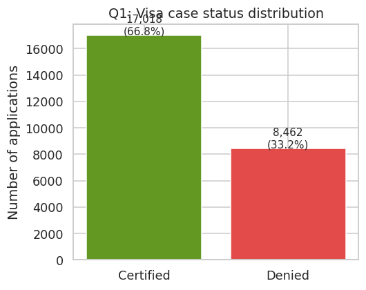

```
Case status distribution:
case_status
Certified    17018
Denied        8462
Name: count, dtype: int64
case_status
Certified    66.8
Denied       33.2
Name: proportion, dtype: float64
```

```python
# Q1. What is the distribution of visa case statuses (certified vs. denied)?
fig, ax = plt.subplots(figsize=(5, 4))
counts = df["case_status"].value_counts()
ax.bar(counts.index, counts.values, color=["#639922", "#E24B4A"], edgecolor="white")
ax.set_title("Q1: Visa case status distribution")
ax.set_ylabel("Number of applications")
for p in ax.patches:
    ax.annotate(f"{int(p.get_height()):,}\n({int(p.get_height())/len(df)*100:.1f}%)",
                (p.get_x() + p.get_width() / 2, p.get_height() + 50),
                ha="center", fontsize=10)
plt.tight_layout()
plt.savefig("eda_q1_status.png")
plt.show()

print("Case status distribution:")
print(df["case_status"].value_counts())
print(df["case_status"].value_counts(normalize=True).mul(100).round(1))
```

**Observations (Q1):**

- 17,018 applications (66.8%) were Certified; 8,462 (33.2%) were Denied.
- The dataset has a 2:1 class imbalance. A naive model predicting "Certified" for all cases would already achieve ~67% accuracy — making accuracy alone a misleading metric. We must monitor Recall and F1 carefully.

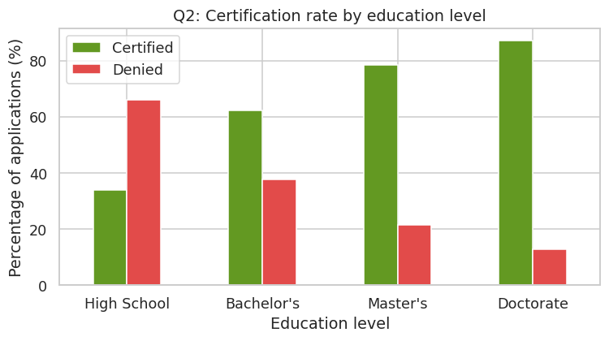

```
Certification rate by education:
case_status            Certified  Denied
education_of_employee
High School                 34.0    66.0
Bachelor's                  62.2    37.8
Master's                    78.6    21.4
Doctorate                   87.2    12.8
```

```python
# Q2. How does education level impact visa approval rates?
edu_order = ["High School", "Bachelor's", "Master's", "Doctorate"]
edu_ct = pd.crosstab(df["education_of_employee"], df["case_status"], normalize="index").mul(100)

fig, ax = plt.subplots(figsize=(7, 4))
edu_ct.reindex(edu_order)[["Certified", "Denied"]].plot(
    kind="bar", ax=ax, color=["#639922", "#E24B4A"], edgecolor="white"
)
ax.set_title("Q2: Certification rate by education level")
ax.set_ylabel("Percentage of applications (%)")
ax.set_xlabel("Education level")
ax.set_xticklabels(edu_order, rotation=0)
ax.legend(loc="upper left")
plt.tight_layout()
plt.savefig("eda_q2_education.png")
plt.show()

print("Certification rate by education:")
print(edu_ct.reindex(edu_order).round(1))
```

**Observations (Q2):**

- Education is the single clearest separator. Doctorate holders are certified at 87%, Master's at 79%, Bachelor's at 62%, and High School-only applicants at just 34%.
- Higher education strongly predicts certification.

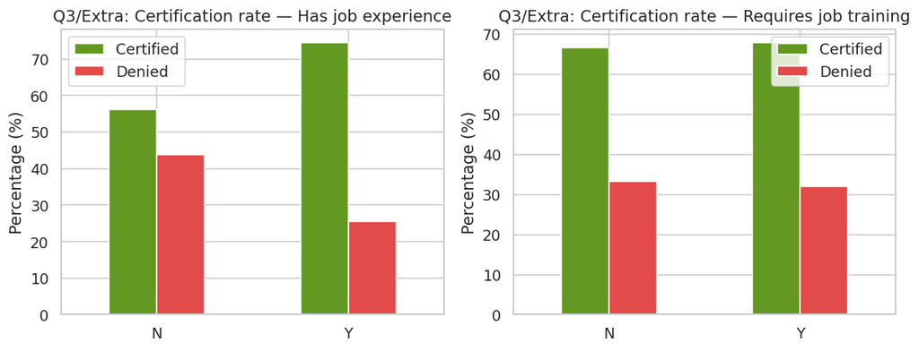

```
Certification rate by job experience:
case_status         Certified  Denied
has_job_experience
N                        56.1    43.9
Y                        74.5    25.5
```

```python
# Q3. Does prior job experience affect approval rates?
fig, axes = plt.subplots(1, 2, figsize=(10, 4))
for ax, col, title in zip(
    axes,
    ["has_job_experience", "requires_job_training"],
    ["Has job experience", "Requires job training"],
):
    ct = pd.crosstab(df[col], df["case_status"], normalize="index").mul(100)
    ct[["Certified", "Denied"]].plot(kind="bar", ax=ax,
                                      color=["#639922", "#E24B4A"], edgecolor="white", rot=0)
    ax.set_title(f"Q3/Extra: Certification rate — {title}")
    ax.set_ylabel("Percentage (%)")
    ax.set_xlabel("")
    ax.legend()
plt.tight_layout()
plt.savefig("eda_q3_experience.png")
plt.show()

print("Certification rate by job experience:")
print(pd.crosstab(df["has_job_experience"], df["case_status"], normalize="index").mul(100).round(1))
```

**Observations (Q3):**

- Applicants with prior job experience (Y) are certified at ~74.5% vs ~56.1% for those without — an 18 percentage-point difference.
- Job training requirement shows a smaller effect and is near the overall average for both Y and N.

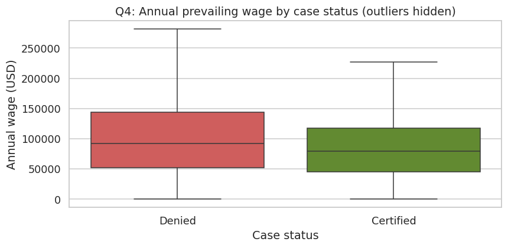

```
Annual wage summary by status:
case_status     Certified        Denied
count        1.701800e+04  8.462000e+03
mean         1.627153e+05  2.671281e+05
std          5.435582e+05  6.376462e+05
min          1.000000e+02  1.531100e+02
25%          4.482344e+04  5.217827e+04
50%          7.937720e+04  9.182732e+04
75%          1.179150e+05  1.439658e+05
max          1.456915e+07  1.195744e+07
```

```python
# Q4. How does prevailing wage affect approval?
fig, ax = plt.subplots(figsize=(8, 4))
sns.boxplot(data=df, x="case_status", y="annual_wage",
            palette={"Certified": "#639922", "Denied": "#E24B4A"},
            showfliers=False, ax=ax)
ax.set_title("Q4: Annual prevailing wage by case status (outliers hidden)")
ax.set_ylabel("Annual wage (USD)")
ax.set_xlabel("Case status")
plt.tight_layout()
plt.savefig("eda_q4_wage.png")
plt.show()

print("Annual wage summary by status:")
print(df.groupby("case_status")["annual_wage"].describe().T)
```

**Observations (Q4):** -The median yearly salary of denied applications is higher ($92K) than that of certified ones ($79K).

- This probably indicates that highly specialized, high-paying jobs are scrutinized more.

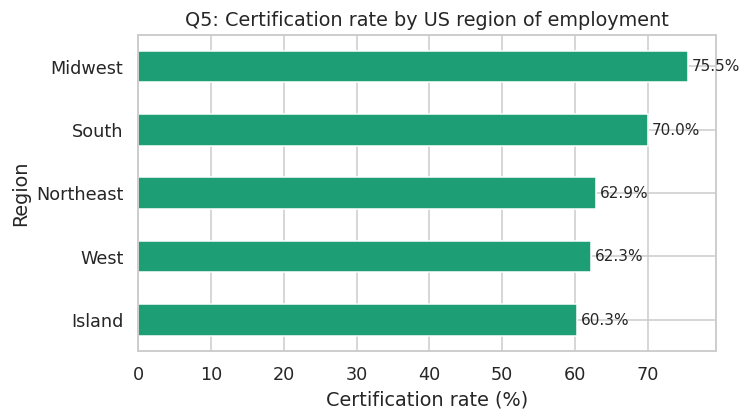

```
Certification rate by region:
case_status           Certified  Denied
region_of_employment
Island                     60.3    39.7
West                       62.3    37.7
Northeast                  62.9    37.1
South                      70.0    30.0
Midwest                    75.5    24.5
```

```python
# Q5. Do certain US regions have higher approval rates?
reg_ct = pd.crosstab(df["region_of_employment"], df["case_status"], normalize="index").mul(100)
fig, ax = plt.subplots(figsize=(7, 4))
reg_ct.sort_values("Certified")["Certified"].plot(
    kind="barh", ax=ax, color="#1D9E75", edgecolor="white"
)
ax.set_title("Q5: Certification rate by US region of employment")
ax.set_xlabel("Certification rate (%)")
ax.set_ylabel("Region")
for i, v in enumerate(reg_ct.sort_values("Certified")["Certified"]):
    ax.text(v + 0.5, i, f"{v:.1f}%", va="center", fontsize=10)
plt.tight_layout()
plt.savefig("eda_q5_region.png")
plt.show()

print("Certification rate by region:")
print(reg_ct.sort_values("Certified").round(1))
```

**Observations (Q5):**

- The Midwest has the highest certification rate (75.5%), followed by the South (70%).
- Island territories and the West have the lowest rates (60–62%).
- Rather than geographic bias, regional variance may be a reflection of the variety of occupations in each location.

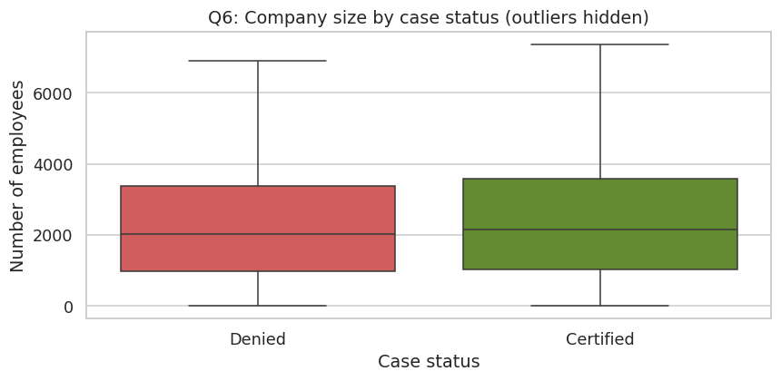

```
Company size summary by status:
case_status      Certified         Denied
count         17018.000000    8462.000000
mean           5807.055882    5385.601040
std           23119.565783   22382.740832
min              11.000000      11.000000
25%            1035.250000     991.000000
50%            2147.000000    2032.500000
75%            3575.000000    3386.750000
max          602069.000000  594472.000000
```

```python
# Q6. Does company size (no_of_employees) influence approval?
# Fix negatives before this analysis
df["no_of_employees"] = df["no_of_employees"].abs()

fig, ax = plt.subplots(figsize=(8, 4))
sns.boxplot(data=df, x="case_status", y="no_of_employees",
            palette={"Certified": "#639922", "Denied": "#E24B4A"},
            showfliers=False, ax=ax)
ax.set_title("Q6: Company size by case status (outliers hidden)")
ax.set_ylabel("Number of employees")
ax.set_xlabel("Case status")
plt.tight_layout()
plt.savefig("eda_q6_company_size.png")
plt.show()

print("Company size summary by status:")
print(df.groupby("case_status")["no_of_employees"].describe().T)
```

**Observations (Q6):**

- Certified applications tend to come from slightly larger companies (higher median no_of_employees), though the difference is modest.

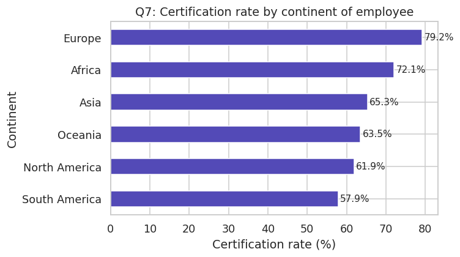

```
Certification rate by continent:
case_status    Certified  Denied
continent
South America       57.9    42.1
North America       61.9    38.1
Oceania             63.5    36.5
Asia                65.3    34.7
Africa              72.1    27.9
Europe              79.2    20.8
```

```python
# Q7. Are approval rates different across continents?
cont_ct = pd.crosstab(df["continent"], df["case_status"], normalize="index").mul(100)
fig, ax = plt.subplots(figsize=(7, 4))
cont_ct.sort_values("Certified")["Certified"].plot(
    kind="barh", ax=ax, color="#534AB7", edgecolor="white"
)
ax.set_title("Q7: Certification rate by continent of employee")
ax.set_xlabel("Certification rate (%)")
ax.set_ylabel("Continent")
for i, v in enumerate(cont_ct.sort_values("Certified")["Certified"]):
    ax.text(v + 0.5, i, f"{v:.1f}%", va="center", fontsize=10)
plt.tight_layout()
plt.savefig("eda_q7_continent.png")
plt.show()

print("Certification rate by continent:")
print(cont_ct.sort_values("Certified").round(1))
```

**Observations (Q7):**

- European applicants have the highest certification rate (79.2%), followed by Africa (72.1%) and Asia (65.3%).
- South American applicants have the lowest rate (57.9%).
- The variation likely reflects the occupational profile of applicants from each region; in the case of South America, the proximity to the US and large number of people intending to migrate there.